# TP_Seaborn

```python
import numpy as np
import pandas as pd
import seaborn as sns

import matplotlib.pyplot as plt
```

## Données

SOURCE DE DONNÉES : https://www.kaggle.com/rikdifos/credit-card-approval-prediction

Informations sur les données :

Les cartes de **credit Scoring** (évaluation des risques) sont une méthode courante de contrôle des risques dans le secteur financier. Il utilise les informations personnelles et les données soumises par les demandeurs de carte de crédit pour prédire la probabilité de futurs défauts de paiement et d'emprunts de carte de crédit. La banque est en mesure de décider d'émettre une carte de crédit au demandeur. Les **Credit Scores** peuvent quantifier objectivement l'ampleur du risque.

Informations sur les Features :

| application_record.csv |  |  |
| --- | --- | --- |
| Feature name | Explanation | Remarks |
| `ID` | Client number |  |
| `CODE_GENDER` | Gender |  |
| `FLAG_OWN_CAR` | Is there a car |  |
| `FLAG_OWN_REALTY` | Is there a property |  |
| `CNT_CHILDREN` | Number of children |  |
| `AMT_INCOME_TOTAL` | Annual income |  |
| `NAME_INCOME_TYPE` | Income category |  |
| `NAME_EDUCATION_TYPE` | Education level |  |
| `NAME_FAMILY_STATUS` | Marital status |  |
| `NAME_HOUSING_TYPE` | Way of living |  |
| `DAYS_BIRTH` | Birthday | Count backwards from current day (0), -1 means yesterday |
| `DAYS_EMPLOYED` | Start date of employment | Count backwards from current day(0). If positive, it means the person currently unemployed. |
| `FLAG_MOBIL` | Is there a mobile phone |  |
| `FLAG_WORK_PHONE` | Is there a work phone |  |
| `FLAG_PHONE` | Is there a phone |  |
| `FLAG_EMAIL` | Is there an email |  |
| `OCCUPATION_TYPE` | Occupation |  |
| `CNT_FAM_MEMBERS` | Family size |  |

```python
# LECTURE CSV à éxécuter
# lecture du fichier de 54,3 MO depuis 3 fichiers CSV depuis Github pour éviter le temps d'importation
# sur Google Colab
list_url = ['https://raw.githubusercontent.com/moncoachdata/MasterClass_DS_ML/main/application_record-1.csv',
            'https://raw.githubusercontent.com/moncoachdata/MasterClass_DS_ML/main/application_record-2.csv',
            'https://raw.githubusercontent.com/moncoachdata/MasterClass_DS_ML/main/application_record-3.csv']

df = pd.concat([pd.read_csv(f) for f in list_url],ignore_index=True)

# Sinon lecture classique en important sur Google Colab ou depuis le chemin exact
# df = pd.read_csv('application_record.csv')
```

```python
df.head()
```

|  | ID | CODE_GENDER | FLAG_OWN_CAR | FLAG_OWN_REALTY | CNT_CHILDREN | AMT_INCOME_TOTAL | NAME_INCOME_TYPE | NAME_EDUCATION_TYPE | NAME_FAMILY_STATUS | NAME_HOUSING_TYPE | DAYS_BIRTH | DAYS_EMPLOYED | FLAG_MOBIL | FLAG_WORK_PHONE | FLAG_PHONE | FLAG_EMAIL | OCCUPATION_TYPE | CNT_FAM_MEMBERS |
| --- | --- | --- | --- | --- | --- | --- | --- | --- | --- | --- | --- | --- | --- | --- | --- | --- | --- | --- |
| 0 | 5008804 | M | Y | Y | 0 | 427500.0 | Working | Higher education | Civil marriage | Rented apartment | -12005 | -4542 | 1 | 1 | 0 | 0 | NaN | 2.0 |
| 1 | 5008805 | M | Y | Y | 0 | 427500.0 | Working | Higher education | Civil marriage | Rented apartment | -12005 | -4542 | 1 | 1 | 0 | 0 | NaN | 2.0 |
| 2 | 5008806 | M | Y | Y | 0 | 112500.0 | Working | Secondary / secondary special | Married | House / apartment | -21474 | -1134 | 1 | 0 | 0 | 0 | Security staff | 2.0 |
| 3 | 5008808 | F | N | Y | 0 | 270000.0 | Commercial associate | Secondary / secondary special | Single / not married | House / apartment | -19110 | -3051 | 1 | 0 | 1 | 1 | Sales staff | 1.0 |
| 4 | 5008809 | F | N | Y | 0 | 270000.0 | Commercial associate | Secondary / secondary special | Single / not married | House / apartment | -19110 | -3051 | 1 | 0 | 1 | 1 | Sales staff | 1.0 |

```python
df.info()
```

```
<class 'pandas.core.frame.DataFrame'>
RangeIndex: 438557 entries, 0 to 438556
Data columns (total 18 columns):
 #   Column               Non-Null Count   Dtype
---  ------               --------------   -----
 0   ID                   438557 non-null  int64
 1   CODE_GENDER          438557 non-null  object
 2   FLAG_OWN_CAR         438557 non-null  object
 3   FLAG_OWN_REALTY      438557 non-null  object
 4   CNT_CHILDREN         438557 non-null  int64
 5   AMT_INCOME_TOTAL     438557 non-null  float64
 6   NAME_INCOME_TYPE     438557 non-null  object
 7   NAME_EDUCATION_TYPE  438557 non-null  object
 8   NAME_FAMILY_STATUS   438557 non-null  object
 9   NAME_HOUSING_TYPE    438557 non-null  object
 10  DAYS_BIRTH           438557 non-null  int64
 11  DAYS_EMPLOYED        438557 non-null  int64
 12  FLAG_MOBIL           438557 non-null  int64
 13  FLAG_WORK_PHONE      438557 non-null  int64
 14  FLAG_PHONE           438557 non-null  int64
 15  FLAG_EMAIL           438557 non-null  int64
 16  OCCUPATION_TYPE      304354 non-null  object
 17  CNT_FAM_MEMBERS      438557 non-null  float64
dtypes: float64(2), int64(8), object(8)
memory usage: 60.2+ MB
```

## MISSIONS

### Re-créez les diagrammes affichés dans les cellules de l'image Markdown. Chaque graphique contient également une brève description de ce qu'il tente de transmettre. Notez que certains tracés sont censés être très difficiles. Commencez par répliquer d'abord la forme la plus élémentaire du tracé, puis essayez d'ajuster son style et ses paramètres pour qu'ils correspondent à l'image donnée.

De façon générale, ne vous souciez pas de la coloration, du style ou de l'exacte correspondance des tailles. Concentrez-vous plutôt sur le contenu du diagramme lui-même. Notre objectif n'est pas de vous tester sur la reconnaissance de figsize=(10,8), c'est de tester votre compréhension et d'être en mesure de visualiser un diagramme attendu et de le reproduire avec votre code Python.

**NOTE : Vous devrez peut-être effectuer des calculs supplémentaires sur le dataframe PAndas avant d'appeler seaborn pour créer le diagramme.**

### Mission 1 : Reproduire le diagramme de dispersion (nuage de points) illustré ci-dessous

**Le diagramme de dispersion tente de montrer la relation entre les jours travaillés et l'âge de la personne (DAYS_BIRTH) pour les personnes qui n'étaient pas sans emploi. Notez que pour reproduire ce graphique, vous devez d'abord supprimer les personnes sans emploi du dataset. Notez également le signe de l'axe, ils sont tous deux transformés pour être positifs. Enfin, n'hésitez pas à ajuster les paramètres *alpha* et *linewidth* dans le nuage de points, car il y a de nombreux points empilés les uns sur les autres.**

[figure not shown]

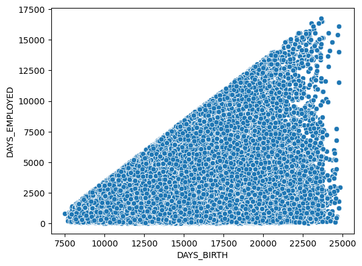

```python
import numpy as np
import pandas as pd
import seaborn as sns

import matplotlib.pyplot as plt

list_url = ['./csv/application_record-1.csv',
            './csv/application_record-2.csv',
            './csv/application_record-3.csv']

df = pd.concat([pd.read_csv(f) for f in list_url],ignore_index=True)

birth = df['DAYS_BIRTH'].abs()
employed = df['DAYS_EMPLOYED'].abs()


employedFiltered = employed[(employed >= 0) & (employed <= 17500)]

# Créer le graphique de dispersion avec les données filtrées
sns.scatterplot(x=birth, y=employedFiltered, data=df)

plt.savefig('BirthEmployed.png')
```

### Mission 2 : Reproduire le diagramme de distribution illustré ci-dessous :

[figure not shown]

**Notez que vous devrez déterminer comment calculer "Âge en années" à partir de l'une des colonnes du dataframe. Réfléchissez bien à cela. Ne vous inquiétez pas trop si vous ne parvenez pas à reproduire exactement le style.**

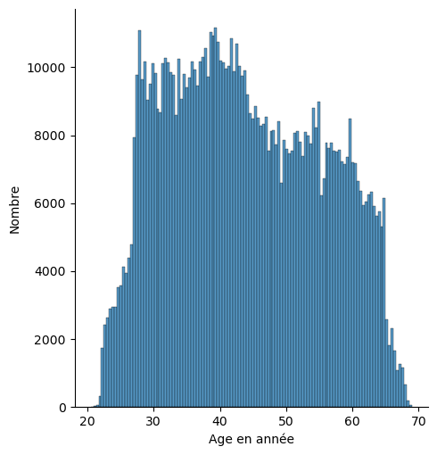

```python
import numpy as np
import pandas as pd
import seaborn as sns

import matplotlib.pyplot as plt

list_url = ['./csv/application_record-1.csv',
            './csv/application_record-2.csv',
            './csv/application_record-3.csv']

df = pd.concat([pd.read_csv(f) for f in list_url],ignore_index=True)

birth = df['DAYS_BIRTH'].abs()

doubled_ages = []
for age in birth:
    doubled_ages.append(age)
    doubled_ages.append(age)


doubled_ages_years = [age / 365.25 for age in doubled_ages]
doubled_ages_years_cleaned = [age for age in doubled_ages_years if not np.isnan(age)]

sns.displot(x=doubled_ages_years_cleaned)
plt.xlabel('Age en année')
plt.ylabel('Nombre')

plt.savefig('Age en année.png')
```

### Mission 3 : Reproduire le diagramme catégoriel illustré ci-dessous :

[figure not shown]

**Ce diagramme présente des informations uniquement pour la *moitié inférieure* des salariés de cet ensemble de données. Il affiche les boîtes à moustaches de chaque catégorie de la colonne 'NAME_FAMILY_STATUS' (situation familiale) pour afficher la distribution de leur revenu total. Le "hue" est la colonne 'FLAG_OWN_REALTY' (propriétaire ou non - Y/N). Remarque : Vous devrez ajuster ou ne prendre qu'une partie du dataframe *avant* de reproduire ce tracé.**

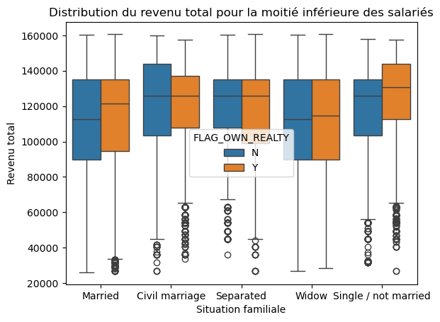

```python
import numpy as np
import pandas as pd
import seaborn as sns
import matplotlib.pyplot as plt

list_url = ['./csv/application_record-1.csv',
            './csv/application_record-2.csv',
            './csv/application_record-3.csv']

df = pd.concat([pd.read_csv(f) for f in list_url], ignore_index=True)

df_sorted = df.sort_values(by='AMT_INCOME_TOTAL')

half_data = df_sorted.iloc[:len(df_sorted)//2]

sns.boxplot(x='NAME_FAMILY_STATUS', y='AMT_INCOME_TOTAL', hue='FLAG_OWN_REALTY', data=half_data)

plt.title('Distribution du revenu total pour la moitié inférieure des salariés')
plt.xlabel('Situation familiale')
plt.ylabel('Revenu total')
plt.savefig('situation familiale.png')
```

### Mission 4 : Reproduire la carte de chaleur illustrée ci-dessous :

[figure not shown]

**Cette carte de chaleur (heatmap) montre la corrélation entre les colonnes numériques du dataframe. Vous pouvez obtenir une corrélation avec .corr(), notez également que la colonne 'FLAG_MOBIL' a une corrélation *NaN* avec toutes les autres colonnes, vous devez donc la supprimer avant d'appeler .corr().**

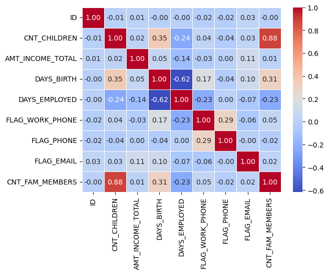

```python
import numpy as np
import pandas as pd
import seaborn as sns
import matplotlib.pyplot as plt

list_url = ['./csv/application_record-1.csv',
            './csv/application_record-2.csv',
            './csv/application_record-3.csv']

df = pd.concat([pd.read_csv(f) for f in list_url], ignore_index=True)

df_numeric = df.drop(columns=['FLAG_MOBIL']).select_dtypes(include=[np.number])

corr = df_numeric.corr()

sns.heatmap(corr, annot=True, cmap='coolwarm', fmt='.2f', linewidths=0.5)
plt.savefig('correlation.png')
```

[figure not shown]

**Bon courage !**